[figure not shown]

# Global Armed Conflict & Civil Unrest

### An Exploratory Analysis of ACLED Data (1997–2026)

# Executive Summary

The objective is to provide a data-driven overview of where violence occurs, how it evolves over time, and which regions and countries are most affected.

# Global Trends in Conflict Events and Fatalities

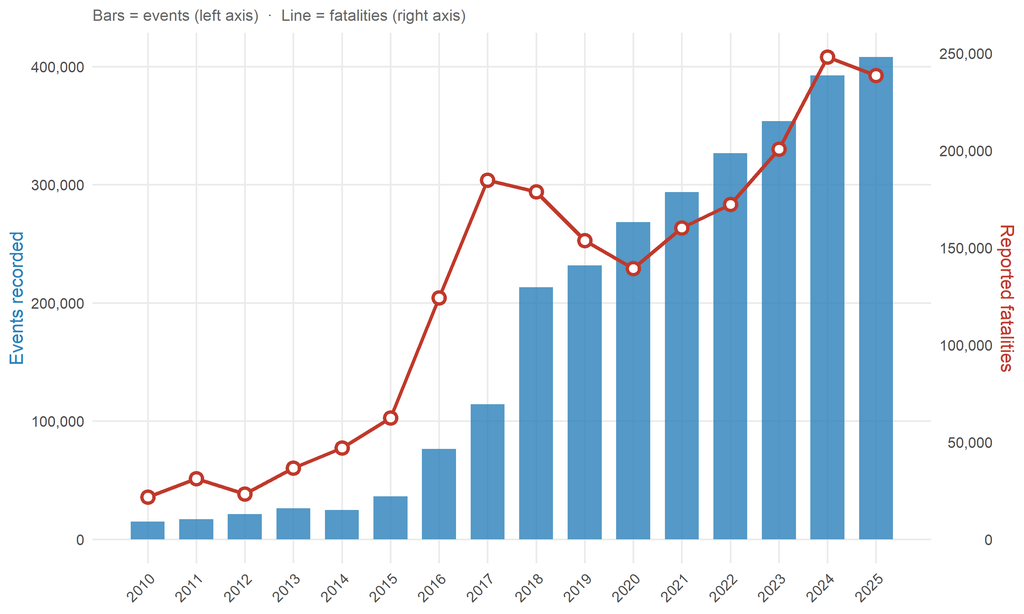

Over the past fifteen years, both the number of conflict events and total fatalities have increased significantly. This indicates that global instability is becoming more frequent and more lethal.

# Global Distribution of Conflict Fatalities

[interactive chart not shown]

This map highlights the unequal global distribution of conflict-related fatalities. A small number of countries account for a disproportionately large share of reported deaths, revealing concentrated conflict hotspots.

# Global Distribution of Conflict Fatalities

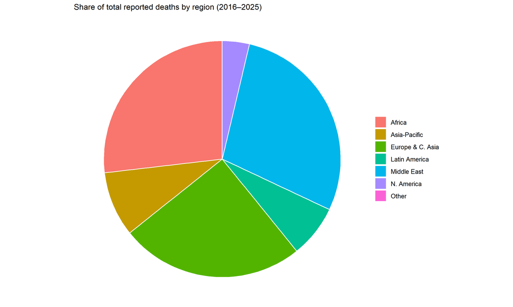

This chart shows how conflict-related fatalities are distributed across global regions. It highlights that a small number of regions account for most of the reported deaths, emphasizing the strong geographic concentration of global conflict.

# Types of Conflict Events by Region

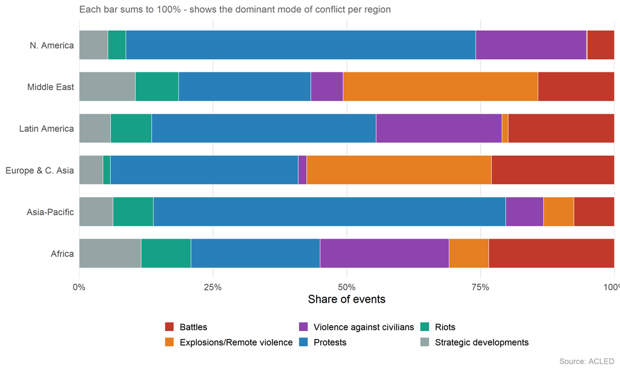

# Top 15 Countries by Conflict Fatalities

[figure not shown]

The countries with the highest total fatalities are not always those with the highest civilian losses. This comparison helps distinguish conflicts primarily affecting combatants from those heavily impacting civilian populations.

# Ukraine Conflict Timeline

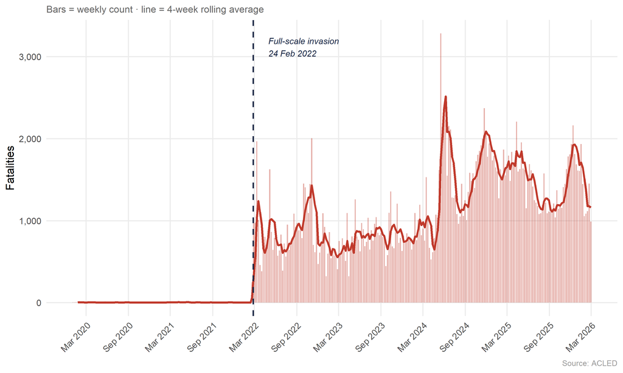

The timeline shows a dramatic escalation following the full-scale invasion in February 2022. This illustrates how a single geopolitical event can rapidly transform both the scale and intensity of violence.

# Pre- and post-2022 shift in global conflict intensity

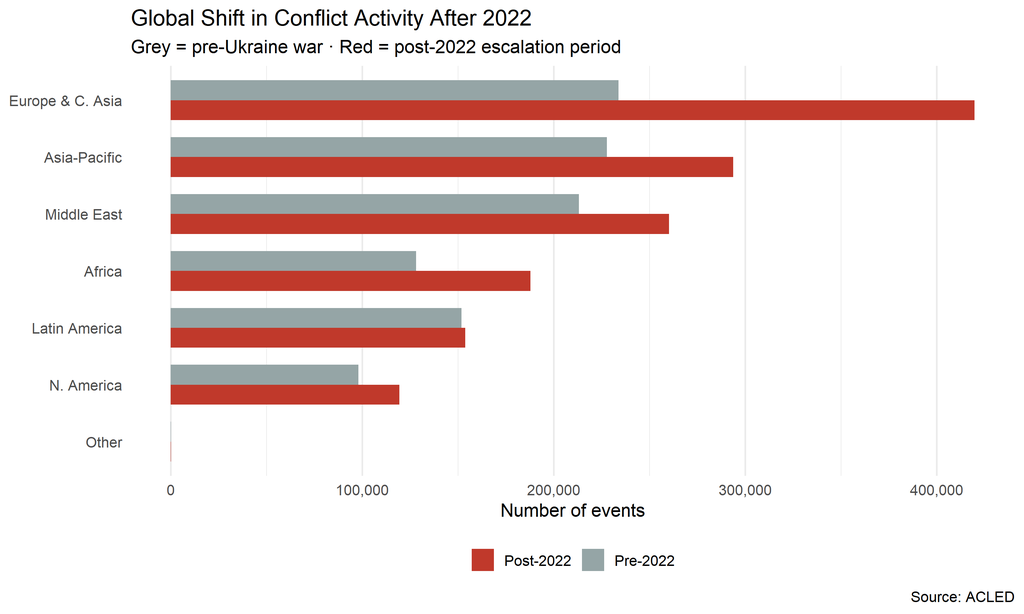

This chart compares conflict activity across regions before and after 2022. It highlights how the intensity of events shifted following 2022, with several regions experiencing a noticeable increase in violence and instability in the post-2022 period.